# Basic R operations

2022-07-23

**Key terms**

- Library:`foreign`; Command: `read.dta()`
- Library: `haven`; command: `read_sav()`
- Command: `read.table()`
- Library: `pdfetch`
- Library: `quantmod`
- Residual
- Residual sum of squares, *RSS*
- Ordinary least squares, *OLS*

# 1 File and directory management

```r
# File and directory Management
# Rscript file: \Rscripts\FileManagement.R

# List all the objects in your local workspace using
ls()
```

```
## character(0)
```

```r
# To demonstrate how to clear an object, we first load an `RData` file into the an R workspace
load(file=url("http://faculty.gvsu.edu/kilburnw/pollingexcerpt.RData"))

# Two objects, `poll` and `poll16` are loaded into the R workspace
ls()
```

```
## [1] "poll"   "poll16"
```

```r
# Clear the objects
rm(poll)
rm(poll16)
ls()
```

```
## character(0)
```

```r
# To clear all the objects in your local workspace, type `rm(list=ls())`
# rm(list=ls())          # Not run


# List all the files in your working directory using
list.files()
```

```
##  [1] "2_RMarkdown.html"     "2_RMarkdown.Rmd"      "3_GitHub.html"
##  [4] "3_GitHub.Rmd"         "4_Visualizing.html"   "4_Visualizing.pdf"
##  [7] "4_Visualizing.Rmd"    "5_DataWrangling.html" "5_DataWrangling.Rmd"
## [10] "Chapter1.html"        "Chapter1.Rmd"         "Chapter6.html"
## [13] "Chapter6.Rmd"         "Data"                 "GitHub.tex"
## [16] "name_of_file.png"     "R4DS.Rproj"           "README.html"
## [19] "README.md"            "Rscripts"             "TemporaryNotes.docx"
```

```r
# or
dir()
```

```
##  [1] "2_RMarkdown.html"     "2_RMarkdown.Rmd"      "3_GitHub.html"
##  [4] "3_GitHub.Rmd"         "4_Visualizing.html"   "4_Visualizing.pdf"
##  [7] "4_Visualizing.Rmd"    "5_DataWrangling.html" "5_DataWrangling.Rmd"
## [10] "Chapter1.html"        "Chapter1.Rmd"         "Chapter6.html"
## [13] "Chapter6.Rmd"         "Data"                 "GitHub.tex"
## [16] "name_of_file.png"     "R4DS.Rproj"           "README.html"
## [19] "README.md"            "Rscripts"             "TemporaryNotes.docx"
```

```r
# Get the current working directory
getwd()
```

```
## [1] "D:/Documents/GitHub/R4DS"
```

```r
# Assign the value of the current working directory to a variable called "old.dir" for later use
old.dir <- getwd()

# Change to a directory by typing the full path
setwd('D:/Documents/GitHub/R4DS/Rscripts')
getwd()
```

```
## [1] "D:/Documents/GitHub/R4DS/Rscripts"
```

```r
# Return to the parent directory (one level up the present directory)
setwd('..')       # or `setwd('../')`
getwd()
```

```
## [1] "D:/Documents/GitHub/R4DS"
```

```r
# Change to a subdirectory
setwd('./Rscripts')
getwd()
```

```
## [1] "D:/Documents/GitHub/R4DS/Rscripts"
```

```r
# Change to a directory by stored variable
setwd(old.dir)
getwd()
```

```
## [1] "D:/Documents/GitHub/R4DS"
```

```r
# Use dir.create() to create a directory in the current working directory called "testdir".
dir.create('testdir')
dir()
```

```
##  [1] "2_RMarkdown.html"     "2_RMarkdown.Rmd"      "3_GitHub.html"
##  [4] "3_GitHub.Rmd"         "4_Visualizing.html"   "4_Visualizing.pdf"
##  [7] "4_Visualizing.Rmd"    "5_DataWrangling.html" "5_DataWrangling.Rmd"
## [10] "Chapter1.html"        "Chapter1.Rmd"         "Chapter6.html"
## [13] "Chapter6.Rmd"         "Data"                 "GitHub.tex"
## [16] "name_of_file.png"     "R4DS.Rproj"           "README.html"
## [19] "README.md"            "Rscripts"             "TemporaryNotes.docx"
## [22] "testdir"
```

```r
# Create a sub-subdirectory
dir.create('testdir/subtestdir1')

# Change to the subdirectory `testdir1` and create a subdirectory here
setwd('./testdir')
dir()
```

```
## [1] "subtestdir1"
```

```r
dir.create('subtestdir2')
dir()
```

```
## [1] "subtestdir1" "subtestdir2"
```

```r
# Moving up one level of the directory (parent directory)
setwd('..')       # or `setwd('../')`
getwd()
```

```
## [1] "D:/Documents/GitHub/R4DS"
```

```r
dir()
```

```
##  [1] "2_RMarkdown.html"     "2_RMarkdown.Rmd"      "3_GitHub.html"
##  [4] "3_GitHub.Rmd"         "4_Visualizing.html"   "4_Visualizing.pdf"
##  [7] "4_Visualizing.Rmd"    "5_DataWrangling.html" "5_DataWrangling.Rmd"
## [10] "Chapter1.html"        "Chapter1.Rmd"         "Chapter6.html"
## [13] "Chapter6.Rmd"         "Data"                 "GitHub.tex"
## [16] "name_of_file.png"     "R4DS.Rproj"           "README.html"
## [19] "README.md"            "Rscripts"             "TemporaryNotes.docx"
## [22] "testdir"
```

```r
# Remove a directory together will all its subdirectories
unlink("testdir", recursive=TRUE)
dir()
```

```
##  [1] "2_RMarkdown.html"     "2_RMarkdown.Rmd"      "3_GitHub.html"
##  [4] "3_GitHub.Rmd"         "4_Visualizing.html"   "4_Visualizing.pdf"
##  [7] "4_Visualizing.Rmd"    "5_DataWrangling.html" "5_DataWrangling.Rmd"
## [10] "Chapter1.html"        "Chapter1.Rmd"         "Chapter6.html"
## [13] "Chapter6.Rmd"         "Data"                 "GitHub.tex"
## [16] "name_of_file.png"     "R4DS.Rproj"           "README.html"
## [19] "README.md"            "Rscripts"             "TemporaryNotes.docx"
```

# 2 Importing data

## 2.1 Loading data of various file format

### 2.1.1 Importing **Stata** data file using package `foreign`

**Library `foreign` no longer support import of Stata file of version 12 and later. We can use the library `haven` instead. The following contents will be updated later. Please also see the reference from the following link: https://www.marsja.se/how-to-read-and-write-stata-dta-files-in-r-with-haven/.**

We first import a **Stata** data file `wage.dta`, which is a data file accompany the book “An Introduction to Classical Econometric Theory (2000)” by Paul A. Ruud.

```r
# Importing data file of various format
# Importing Stata data file into R

library(foreign)               # Load the required package

DTAdata <- read.dta("./Data/wage.dta")
head(DTAdata)
```

```
##       w fe nw un ed ex age wk
## 1 11.55  1  0  0 12 20  38  1
## 2  5.00  0  0  0  9  9  24  0
## 3 12.00  0  0  0 16 15  37  1
## 4  7.00  0  1  1 14 38  58  0
## 5 21.15  1  1  0 16 19  41  1
## 6  6.92  1  0  0 12  4  22  1
```

A further example is to import an **Stata** data file from the internet.

```r
# Further example of importing Stata data file from internet

affairs <- read.dta("http://fmwww.bc.edu/ec-p/data/wooldridge/affairs.dta")
head(affairs)
```

```
##   id male age yrsmarr kids relig educ occup ratemarr naffairs affair vryhap
## 1  4    1  37    10.0    0     3   18     7        4        0      0      0
## 2  5    0  27     4.0    0     4   14     6        4        0      0      0
## 3  6    1  27     1.5    0     3   18     4        4        3      1      0
## 4 11    0  32    15.0    1     1   12     1        4        0      0      0
## 5 12    0  27     4.0    1     3   17     1        5        3      1      1
## 6 16    1  57    15.0    1     5   18     6        5        0      0      1
##   hapavg avgmarr unhap vryrel smerel slghtrel notrel
## 1      1       0     0      0      0        1      0
## 2      1       0     0      0      1        0      0
## 3      1       0     0      0      0        1      0
## 4      1       0     0      0      0        0      0
## 5      0       0     0      0      0        1      0
## 6      0       0     0      1      0        0      0
```

### 2.1.2 Importing **SPSS** data file using package `haven`

We import a **SPSS** data file `Cats and Dogs.sav`, which is a data file accompany the book “Discovering Statistics Using IBM SPSS Statistics (2018)” by Andy Field.

```r
# Importing SPSS data file into R

library(haven)               # Load the required package

SPSSdata <- read_sav("./Data/Cats and Dogs.sav")
head(SPSSdata)
```

```
## # A tibble: 6 × 3
##      Animal           Training     Dance
##   <dbl+lbl>          <dbl+lbl> <dbl+lbl>
## 1   0 [Cat] 0 [Food as Reward]   1 [Yes]
## 2   0 [Cat] 0 [Food as Reward]   1 [Yes]
## 3   0 [Cat] 0 [Food as Reward]   1 [Yes]
## 4   0 [Cat] 0 [Food as Reward]   1 [Yes]
## 5   0 [Cat] 0 [Food as Reward]   1 [Yes]
## 6   0 [Cat] 0 [Food as Reward]   1 [Yes]
```

Objects are created in the `R` environment when importing the data. We can delete these objects by the following commands.

```r
# Display the objects created when importing the data files
ls()
```

```
## [1] "affairs"  "DTAdata"  "old.dir"  "SPSSdata"
```

```r
# Removing the objects
rm(DTAdata)
rm(SPSSdata)
rm(affairs)
```

The complete listing of `R` commands for importing data of various format is stored in the following Rscript file: “/Rscripts/LoadData.R”

## 2.2 Importing data from internet

The following is adapted from Example 1.13[^1] (Digits of $\pi$) of the book “R by Example” by Jim Albert and Mraia Rizzo. The data file “PiDigits.dat[^2]” contains the first 5000 digits of the mathematical constant $\pi =3.1415926535897932384\dots$. The data is one of the Statistical Reference Datasets provided by the National Institute of Standards and Technology (NIST). 2 Documentation is inserted at the top of the file, and the digits start on line 61. We use the `read.table` function with the complete URL (web address) and skip=60 to read the data starting at line 61. The URL should be enclosed in quotes and on a single line; otherwise an error message “cannot open the connection” occurs.

```r
#Import data from internet
#Example 1.13 of the book "R by Example"
#Rscript file: \Rscripts\RbyEG_EG1_13.R

# Read in the data
pidigits = read.table(
  "http://www.itl.nist.gov/div898/strd/univ/data/PiDigits.dat",
  skip=60)
head(pidigits)
```

```
##   V1
## 1  3
## 2  1
## 3  4
## 4  1
## 5  5
## 6  9
```

```r
#Summarize the digits in a table by 'table' function
table(pidigits)
```

```
## V1
##   0   1   2   3   4   5   6   7   8   9
## 466 531 496 461 508 525 513 488 491 521
```

```r
#Calculate the proportions of the digits
prop <- table(pidigits) / 5000
prop
```

```
## V1
##      0      1      2      3      4      5      6      7      8      9
## 0.0932 0.1062 0.0992 0.0922 0.1016 0.1050 0.1026 0.0976 0.0982 0.1042
```

```r
#Standard error (se) of the proportion with known proportion
sqrt(.1*.9 / 5000)
```

```
## [1] 0.004242641
```

```r
#For unknow proportion, sample se is calculated
se.hat <- sqrt(prop * (1 - prop) / 5000)
se.hat
```

```
## V1
##           0           1           2           3           4           5
## 0.004111296 0.004357099 0.004227514 0.004091434 0.004272644 0.004335320
##           6           7           8           9
## 0.004291229 0.004197005 0.004208486 0.004320703
```

```r
#The sample proportion plus or minus two standard errors using vectorized arithmetic
round(rbind(prop, se.hat, prop-2*se.hat, prop+2*se.hat), 4)
```

```
##             0      1      2      3      4      5      6      7      8      9
## prop   0.0932 0.1062 0.0992 0.0922 0.1016 0.1050 0.1026 0.0976 0.0982 0.1042
## se.hat 0.0041 0.0044 0.0042 0.0041 0.0043 0.0043 0.0043 0.0042 0.0042 0.0043
##        0.0850 0.0975 0.0907 0.0840 0.0931 0.0963 0.0940 0.0892 0.0898 0.0956
##        0.1014 0.1149 0.1077 0.1004 0.1101 0.1137 0.1112 0.1060 0.1066 0.1128
```

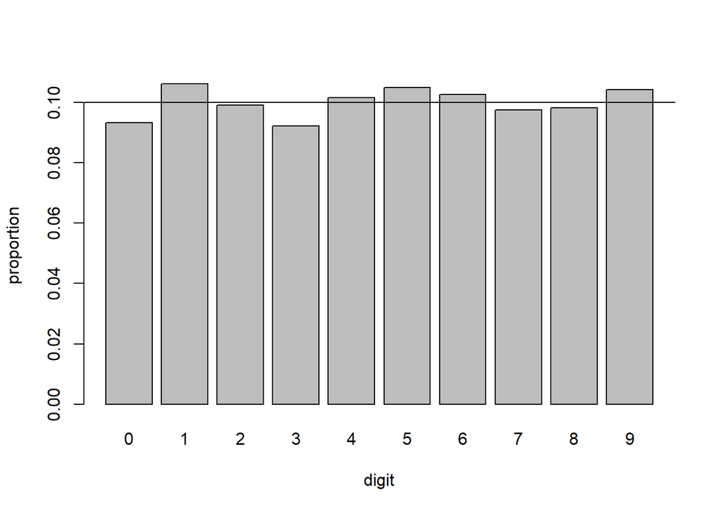

```r
#A barplots helps to visualize the tabulatd data
barplot(prop, xlab="digit", ylab="proportion")
abline(h = .1)
```

## 2.3 Getting financial data from Yahoo using the package `pdfetch`

```r
# Getting financial data from Yahoo using the package `pdfetch`
# Rscript file: /Rscripts/pdfetch.R

library(pdfetch)       # Load the `pdfetch` package

tickernames <- c("0001.HK","0005.HK")
HKStocks <- pdfetch_YAHOO(tickernames, fields="adjclose",from="2018-01-01")
nrow(HKStocks)
```

```
## [1] 1171
```

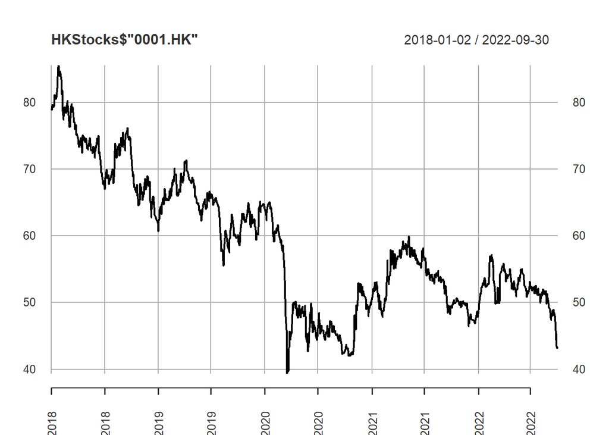

```r
plot(HKStocks$"0001.HK", las=2)
```

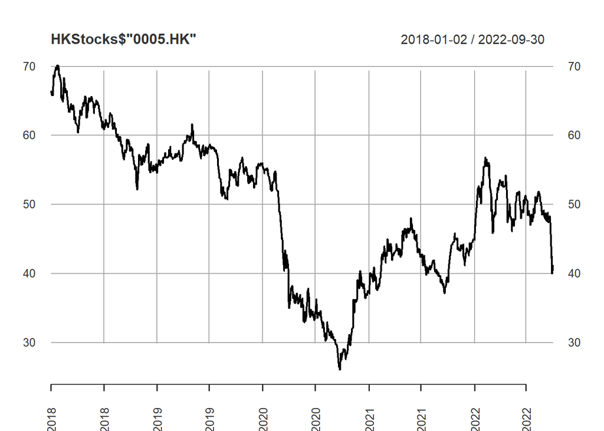

```r
plot(HKStocks$"0005.HK", las=2)
```

## 2.4 Retrieving economic data from the internet using the package `quantmod`

The package `quantmod` is used to retrieve financial data from the internet such as Yahoo Finance and the Federal Reserve Economic Data (FRED) of Federal Reserve Bak of St. Louis.  
First, we demonstrate how to retrieve stock prices from Yahoo Finance.

```r
# Retrieve economic data from the internet using the `quantmod` package
# Rscript file: \Rscripts\quantmod_Yahoo_US.R

# Retrieve stock price from Yahoo Finance
# Load the required package
library(quantmod)       #Alternatively `require(quantmod)`

#Get Apple stock price
getSymbols("AAPL",from="2008-01-03",to="2015-01-28")
```

```
## [1] "AAPL"
```

```r
#See the size of the loaded data set
dim(AAPL)
```

```
## [1] 1779    6
```

```r
#See the first and last 6 row of data
head(AAPL)
```

```
##            AAPL.Open AAPL.High AAPL.Low AAPL.Close AAPL.Volume AAPL.Adjusted
## 2008-01-03  6.978929  7.049643 6.881786   6.961786   842066400      5.944195
## 2008-01-04  6.837500  6.892857 6.388929   6.430357  1455832000      5.490445
## 2008-01-07  6.473214  6.557143 6.079643   6.344286  2072193200      5.416954
## 2008-01-08  6.433571  6.516429 6.100000   6.116071  1523816000      5.222096
## 2008-01-09  6.117857  6.410714 6.010714   6.407143  1813882000      5.470623
## 2008-01-10  6.342143  6.464286 6.264643   6.357857  1482975200      5.428541
```

```r
tail(AAPL)
```

```
##            AAPL.Open AAPL.High AAPL.Low AAPL.Close AAPL.Volume AAPL.Adjusted
## 2015-01-20   26.9600   27.2425  26.6250    27.1800   199599600      24.50652
## 2015-01-21   27.2375   27.7650  27.0675    27.3875   194303600      24.69361
## 2015-01-22   27.5650   28.1175  27.4300    28.1000   215185600      25.33603
## 2015-01-23   28.0750   28.4375  27.8825    28.2450   185859200      25.46676
## 2015-01-26   28.4350   28.5900  28.2000    28.2750   222460000      25.49381
## 2015-01-27   28.1050   28.1200  27.2575    27.2850   382274800      24.60119
```

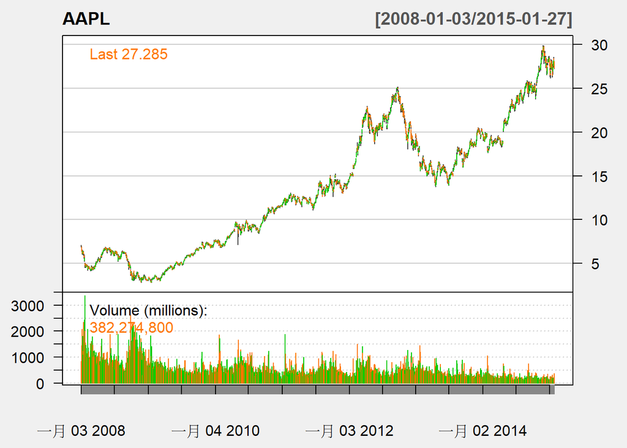

```r
#Obtain time plot of closing price and trading volume
#The subcommand theme="white" set the background of the time plot
#The default is black
chartSeries(AAPL,theme="white")
```

# 3 Find and Count Unique Values

```r
library(tidyverse)

nycflights13::flights %>%
  print(n = 10, width = Inf)
```

```
## # A tibble: 336,776 × 19
##     year month   day dep_time sched_dep_time dep_delay arr_time sched_arr_time
##    <int> <int> <int>    <int>          <int>     <dbl>    <int>          <int>
##  1  2013     1     1      517            515         2      830            819
##  2  2013     1     1      533            529         4      850            830
##  3  2013     1     1      542            540         2      923            850
##  4  2013     1     1      544            545        -1     1004           1022
##  5  2013     1     1      554            600        -6      812            837
##  6  2013     1     1      554            558        -4      740            728
##  7  2013     1     1      555            600        -5      913            854
##  8  2013     1     1      557            600        -3      709            723
##  9  2013     1     1      557            600        -3      838            846
## 10  2013     1     1      558            600        -2      753            745
##    arr_delay carrier flight tailnum origin dest  air_time distance  hour minute
##        <dbl> <chr>    <int> <chr>   <chr>  <chr>    <dbl>    <dbl> <dbl>  <dbl>
```

[output cut: 23 more lines]

```r
n_distinct(nycflights13::flights$origin)
```

```
## [1] 3
```

```r
unique(nycflights13::flights$origin)
```

```
## [1] "EWR" "LGA" "JFK"
```

```r
table(nycflights13::flights$origin)
```

```
##
##    EWR    JFK    LGA
## 120835 111279 104662
```

# 4 Unclassified contents

**Examples in create table**

| First Header | Second Header |
| --- | --- |
| Content Cell | Content Cell |
| Content Cell | Content Cell |

Reference Style Links and Images

**Example in creating table by `knitr::kable()`**

```r
knitr::kable(iris[1:5, ], caption = 'A caption')
```

A caption

| Sepal.Length | Sepal.Width | Petal.Length | Petal.Width | Species |
| --- | --- | --- | --- | --- |
| 5.1 | 3.5 | 1.4 | 0.2 | setosa |
| 4.9 | 3.0 | 1.4 | 0.2 | setosa |
| 4.7 | 3.2 | 1.3 | 0.2 | setosa |
| 4.6 | 3.1 | 1.5 | 0.2 | setosa |
| 5.0 | 3.6 | 1.4 | 0.2 | setosa |

**Obtain predicted values, residuals and anova of `lm()`**

```r
# EARNINGS regress on schooling
library(dplyr)
eawe21 <- read.csv('./Data/EAWE21.csv', header=T)   # Import data
lm(EARNINGS ~ S, data = eawe21) %>%
  anova
```

```
## Analysis of Variance Table
##
## Response: EARNINGS
##            Df Sum Sq Mean Sq F value    Pr(>F)
## S           1   6014  6014.0  46.568 2.579e-11 ***
## Residuals 498  64315   129.1
## ---
## Signif. codes:  0 '***' 0.001 '**' 0.01 '*' 0.05 '.' 0.1 ' ' 1
```

(Please the website https://rc2e.com/linearregressionandanova for more information on regression output.)

[^1]: See Jim Albert and Maria Rizzo, *R by Example*, Springer, New York, 2012, pp. 30.
[^2]: The text file has been downloaded and saved in the sub-directory ”Data.”